# R mini-course: week 3 notes

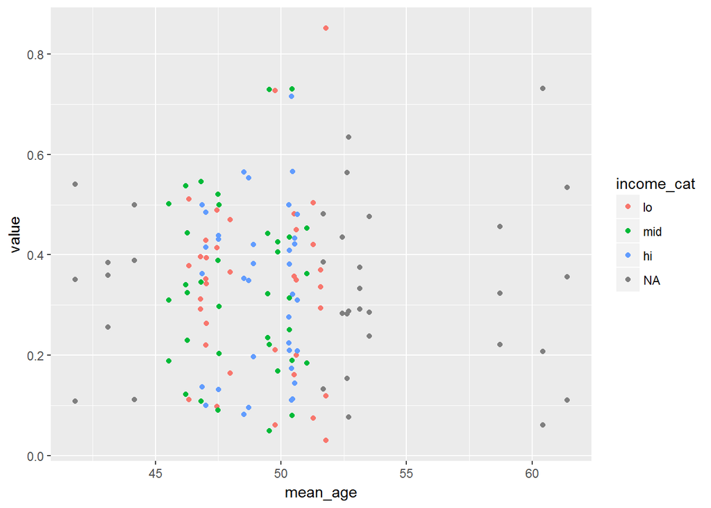

```r
ggplot(pdat, aes(x=mean_age, y=value, color=income_cat)) +
  geom_point()
```

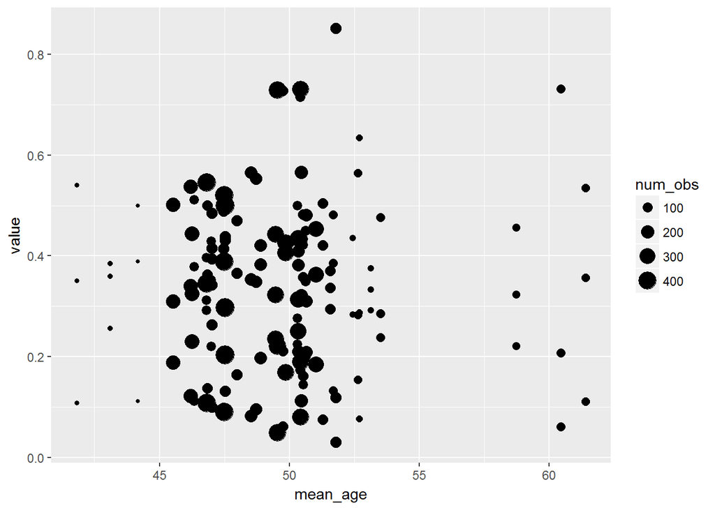

```r
# size-coded
ggplot(pdat, aes(x=mean_age, y=value, size=num_obs)) +
  geom_point()
```

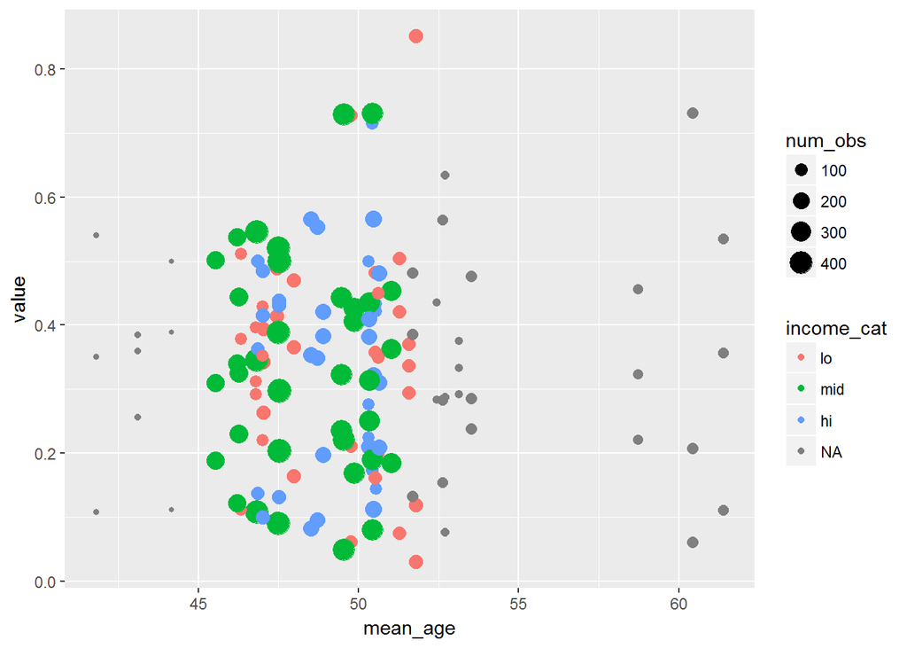

```r
# size- and color-coded
ggplot(pdat, aes(x=mean_age, y=value, size=num_obs, color=income_cat)) +
  geom_point()
```

**exercise**: how could we get rid of the `NA`’s in the plot with color coding for `income_cat`?

Now let’s look at how the responses are distributed for individual items:

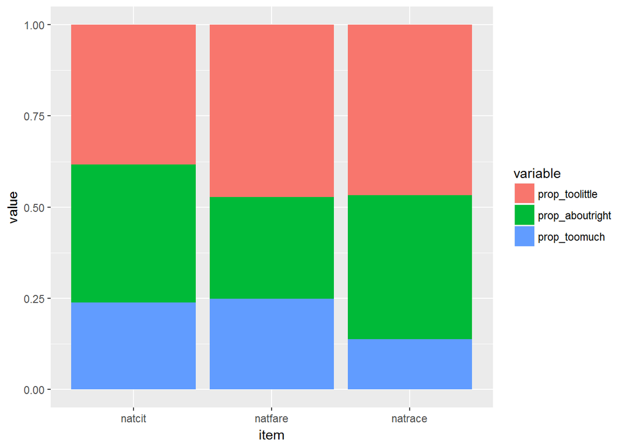

```r
# first group the data by item and get proportions for each response
boosh <- dat %>% group_by(item) %>% summarize(
  prop_toolittle  = sum(response=="too little", na.rm=TRUE) / n(),
  prop_aboutright = sum(response=="about right", na.rm=TRUE) / n(),
  prop_toomuch = sum(response=="too much", na.rm=TRUE) / n()
) %>% melt(id.vars="item")

# now make some plots
ggplot(boosh, aes(x=item, y=value, fill=variable)) + geom_bar(stat="identity")
```

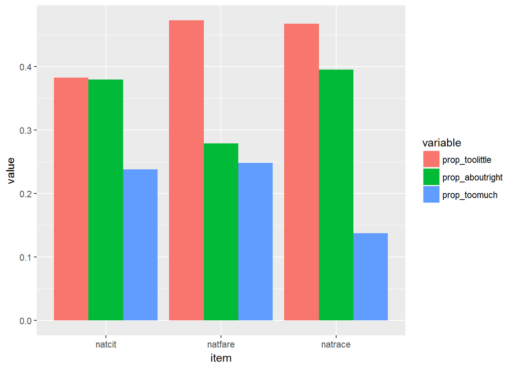

```r
ggplot(boosh, aes(x=item, y=value, fill=variable)) +
  geom_bar(stat="identity", position="dodge")
```

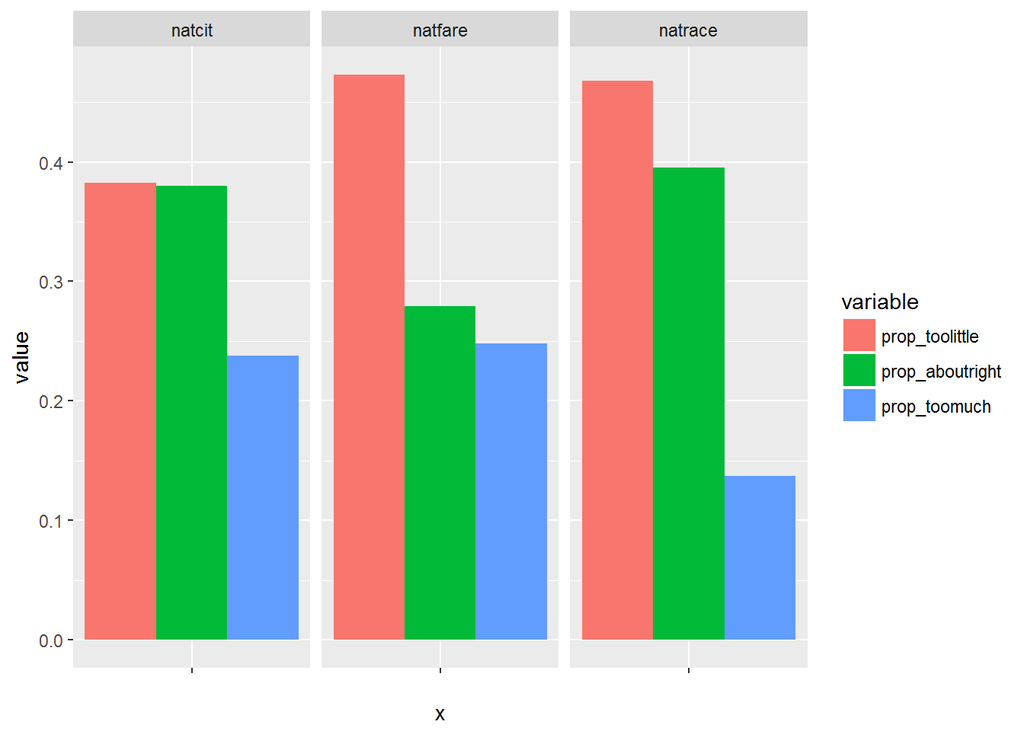

```r
ggplot(boosh, aes(x="", y=value, fill=variable)) +
  geom_bar(stat="identity", position="dodge") +
  facet_wrap(~item)
```

Now let’s see if `form` looks like it has an effect on responses!

```r
# first group the data by item and get proportions for each response
boosh <- dat %>% group_by(item, form) %>% summarize(
  prop_toolittle  = sum(response=="too little", na.rm=TRUE) / n(),
  prop_aboutright = sum(response=="about right", na.rm=TRUE) / n(),
  prop_toomuch = sum(response=="too much", na.rm=TRUE) / n()
) %>% melt(id.vars=c("item","form")) %>% data.frame()

knitr::kable(boosh)
```

| item | form | variable | value |
| --- | --- | --- | --- |
| natcit | assistance | prop_toolittle | 0.2419734 |
| natcit | standard | prop_toolittle | 0.5193916 |
| natfare | assistance | prop_toolittle | 0.7141839 |
| natfare | standard | prop_toolittle | 0.2281588 |
| natrace | assistance | prop_toolittle | 0.4155642 |
| natrace | standard | prop_toolittle | 0.5193199 |
| natcit | assistance | prop_aboutright | 0.4142522 |
| natcit | standard | prop_aboutright | 0.3460076 |
| natfare | assistance | prop_aboutright | 0.2145403 |
| natfare | standard | prop_aboutright | 0.3444043 |
| natrace | assistance | prop_aboutright | 0.4163424 |
| natrace | standard | prop_aboutright | 0.3740340 |
| natcit | assistance | prop_toomuch | 0.3437745 |
| natcit | standard | prop_toomuch | 0.1346008 |
| natfare | assistance | prop_toomuch | 0.0712758 |
| natfare | standard | prop_toomuch | 0.4274368 |
| natrace | assistance | prop_toomuch | 0.1680934 |
| natrace | standard | prop_toomuch | 0.1066461 |

We can plot this in a number of ways – each providing a slightly different perspective on the data. (generally speaking, *not* all perspectives are equally useful/sensical!)

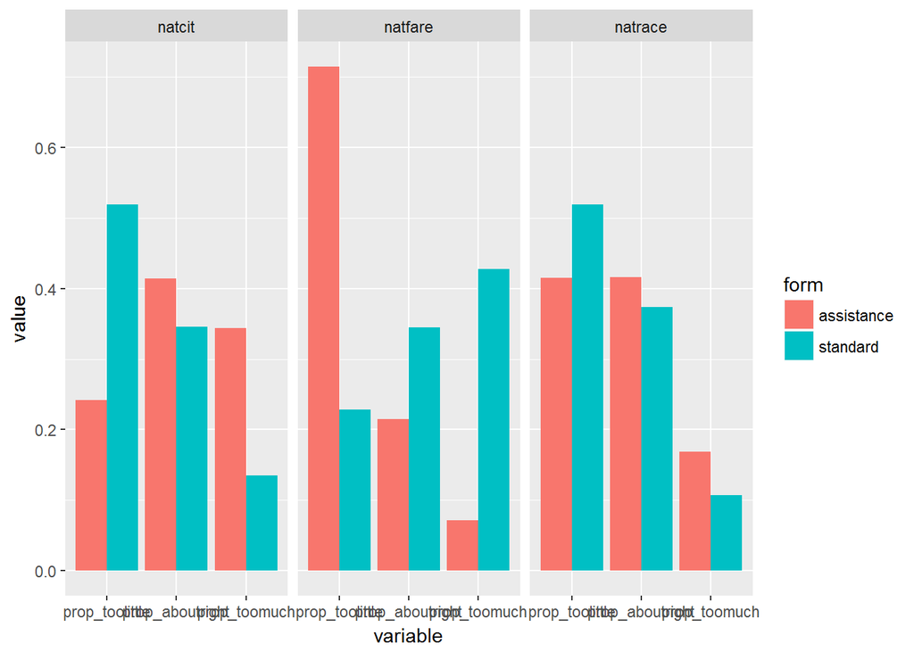

```r
ggplot(boosh, aes(x=variable, y=value, fill=form)) +
  geom_bar(stat="identity", position="dodge") +
  facet_wrap(~item)
```

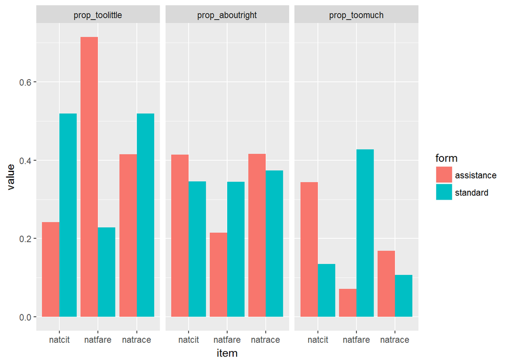

```r
ggplot(boosh, aes(x=item, y=value, fill=form)) +
  geom_bar(stat="identity", position="dodge") +
  facet_wrap(~variable)
```

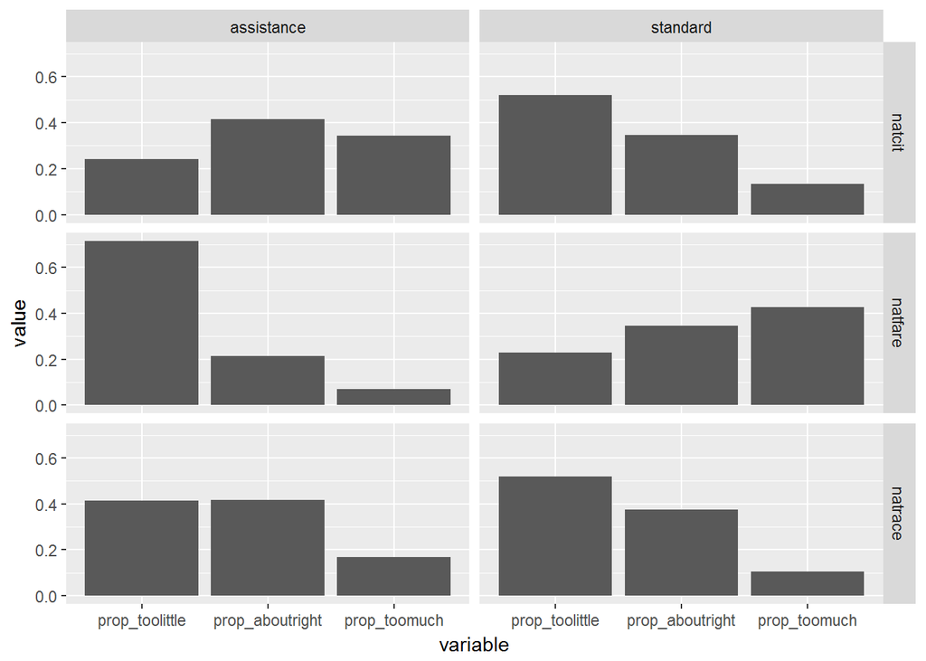

```r
ggplot(boosh, aes(x=variable, y=value)) +
  geom_bar(stat="identity", position="dodge") +
  facet_grid(item ~ form)
```

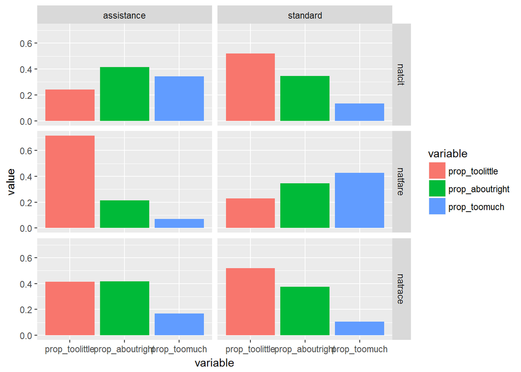

```r
ggplot(boosh, aes(x=variable, y=value, fill=variable)) +
  geom_bar(stat="identity", position="dodge") +
  facet_grid(item~form)
```

**exercise**: what should we expect `sum(boosh$value)` to evaluate to? Why?

#### 4.4 styling and saving plots!

For notes on styling `ggplot2` plots, check out [the week3 script](http://lefft.xyz/r_minicourse/week3_materials/week3_script.r). Here’s a few of the things we went over in class, all of which you’ll find in that script:

- control the color coding
- move the legend position
- label the axes and plot
- add a caption
- add labels for the values
- axis limits and axis ticks
- …

Two basic ways to save a `ggplot2::` plot object are:

1. via the “export” interface in R Studio
2. via the function `ggsave()` (see [week3 script](http://lefft.xyz/r_minicourse/week3_materials/week3_script.r))

You can specify the dimensions and filetype etc. with the “export” interface. You can do the same with `ggsave()`, *but* the latter has a few advantages:

- if you save a plot with a command instead of point-and-click, you’ll never forget what size you saved it as! That way, if you need to update the figure, you can just re-run the code.
- you can save a bunch of plots automatically as a by-product of just running your script.
- you can do fun stuff like the animation in the appendix :p

### next week

- document authoring with R Markdown:
  - everyone will create one quick R Markdown document together;
  - then everyone will create their own with their own dataset!
- if time, *very* quick/incomplete intro to web-scraping in R
- if time, whatever else yall want to talk about/do!

### Appendix: using `for`-loops to make animated gif plots!

Title is hopefully self-explanatory! Check out the super fun + cool `magick::` package (esp. [this nice vignette](https://cran.r-project.org/web/packages/magick/vignettes/intro.html)), which allows you to call image-magick functions directly from R.

**exercise**: mark up the code below with comments explaining what’s happening in each step or line of code, and why. (places where I’d suggest putting comments are marked with `# [comment here]` – writing lots of comments is a good way to reinforce stuff in your memory)

```r
library("ggplot2")
library("magick")

# [comment here]
df <- data.frame(
  time_worked = rep(seq(0, 1.4, .2), times=2),
  amount_done = c(seq(0, 4, .8)^2, 50, 100, seq(0, 9, 2)^2, 85, 90, 95),
  strategy    = rep(c("writing code", "point and click"), each=8)
)
# [comment here]
df <- arrange(df, time_worked)

# [comment here]
for (x in seq(from=2, to=nrow(df), by=2)){
  # [comment here]
  myplot <-
    ggplot(df[1:x, ], aes(x=time_worked, y=amount_done, color=strategy)) +
    # [comment here]
    geom_point() +
    # [comment here]
    geom_line() +
    # [comment here]
    scale_x_continuous(limits=c(0, 1.5)) +
    scale_y_continuous(limits=c(0, 100)) +
    # [commment here]
    theme(legend.position="top",
          axis.text=element_blank())

  # [comment here]
  fname_digit <- ifelse(x < 10, paste0("0", x), as.character(x))

  # [comment here]
  ggsave(
    filename=paste0("plots/myplot", fname_digit, ".png"), plot=myplot,
    width=7, height=5, units="in"
  )

}

# [comment here]
gifcap <- c("yayyy, animated gif plot! \nwoop woop ~~ <(o_@)^")

# [comment here]
dir("plots/")[endsWith(dir("plots/"), ".png")] %>%
  (function(x) paste0("plots/", x)) %>%
  # [comment here]
  image_read() %>%
  image_scale("x600") %>%
  # [comment here]
  image_join() %>%
  image_animate(fps=2) %>%
  # [comment here]
  image_annotate(gifcap, location="+100+100", color="green", size=30) %>%
  # [comment here]
  image_write(path="output/animate_woop_woop.gif", quality=10)
```

Aaaand here’s what we end up with:

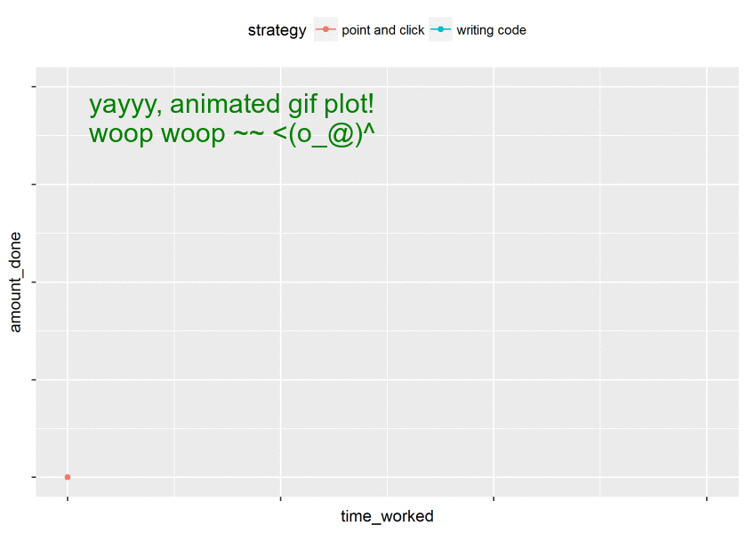